# Reversal Data Cleaning and Diagnostics - Old

### rts 8

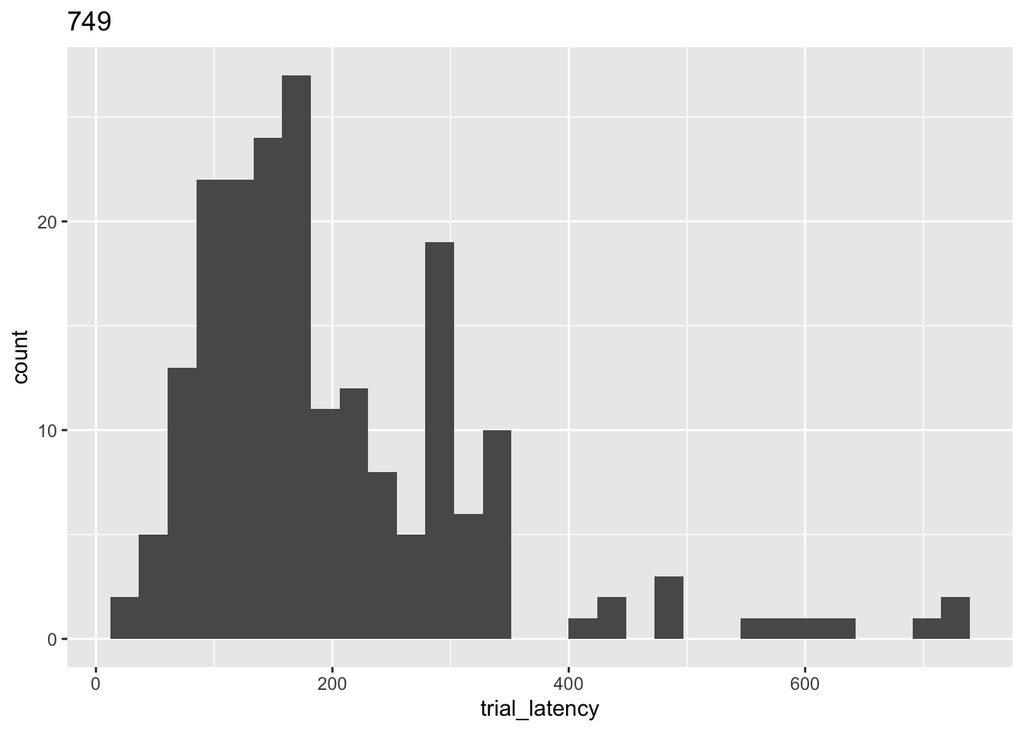

### rts 9

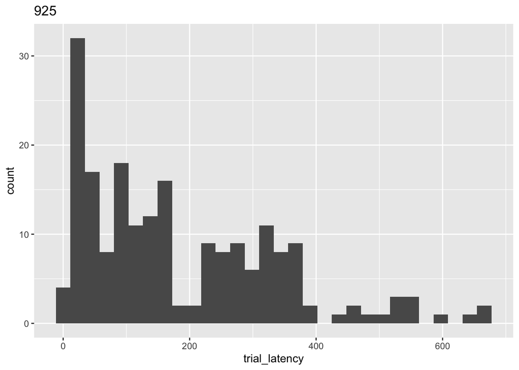

### rts 10

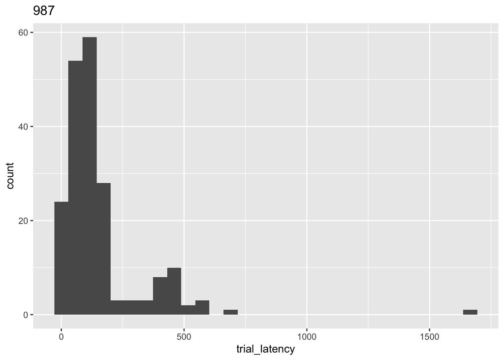

### rts 11

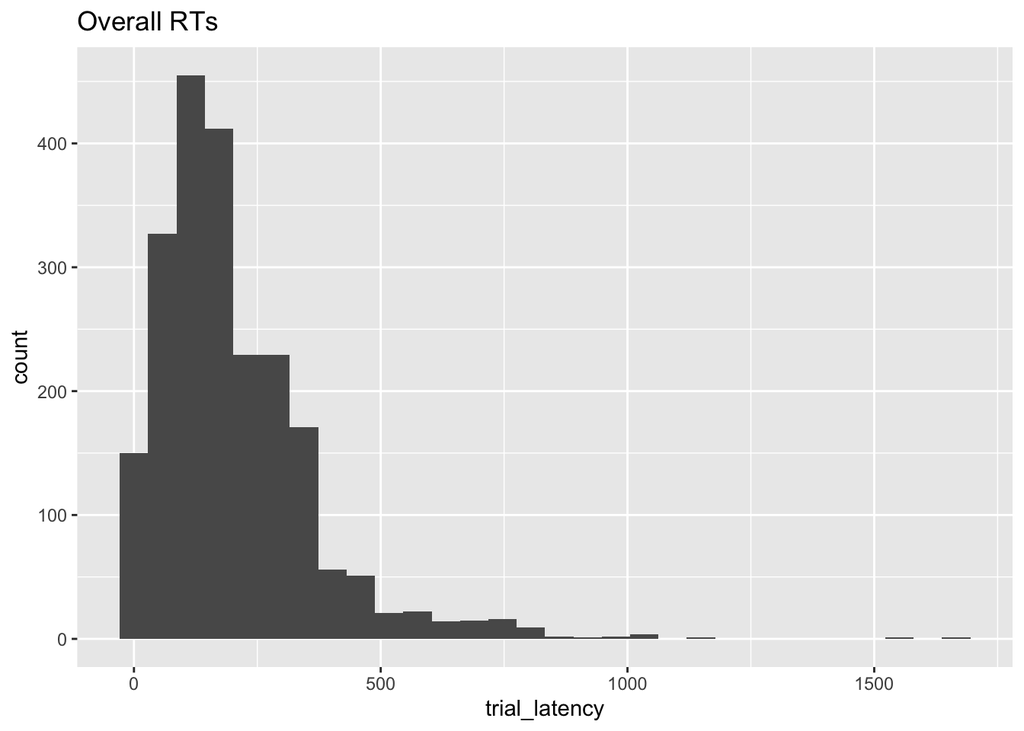

```r
for (i in subjects) {
  d <- reversal %>% dplyr::filter(subject == i)
  scatter <- ggplot(d, aes(x=trial_number, y= trial_response, color = as.factor(isResponse_num))) +
     geom_point() +
     geom_vline(aes(xintercept = reversal_trial, color = "Reversal Point")) +
     scale_color_manual(labels = c("Incorrect", "Correct", "Reversal Point"),
                        values = (wes_palette("Cavalcanti1")[c(5,4,2)])) +
     xlab("Trial Number") + ylab("Response Type") + ggtitle(i) +
     facet_wrap(~block_number)
  scatter[[i]] <- scatter
h <- by_block_phase %>% filter(subject == i) %>% group_by(task_phase)
hist <- ggplot(h, aes(y=percent_correct_phase, x = task_phase, fill = above_threshold)) +
  geom_bar(stat = "identity") +
  scale_fill_manual(values = (wes_palette("Cavalcanti1")[c(4,5)])) +
 ylab("Percentage Correct") + xlab("") +  facet_grid(~ block_number)
 hist[[i]] <- hist
 plot_subjects[[i]] <- list(scatter, hist)

 cowplot <- cowplot::plot_grid(scatter, hist, nrow = 2)
 cowplot_list[[i]] <- cowplot
}
```

## Summary of Reversal Findings

````r
template <- c(
    "### cowplot_list {{y}}\n",
    "```{r, echo = FALSE}\n",
    "cowplot_list[[{{y}}]] \n",
    "```\n",
    "\n"
  )

plots <- lapply(1:length(cowplot_list), function(y) {knitr::knit_expand(text = template)})
````

### cowplot_list 1

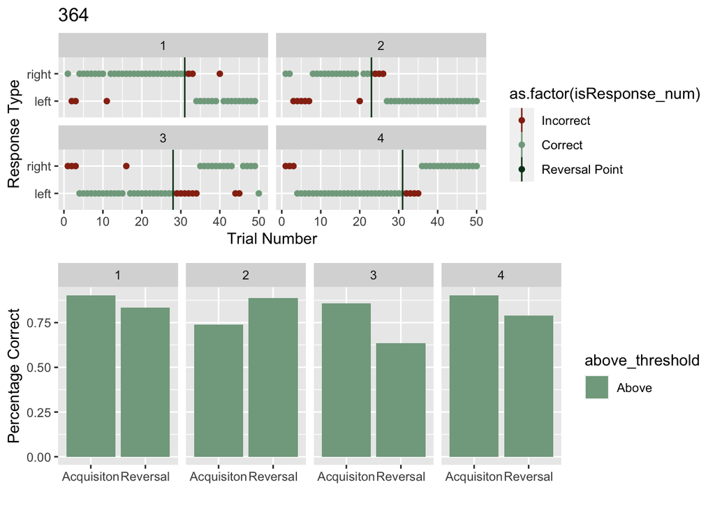

### cowplot_list 2

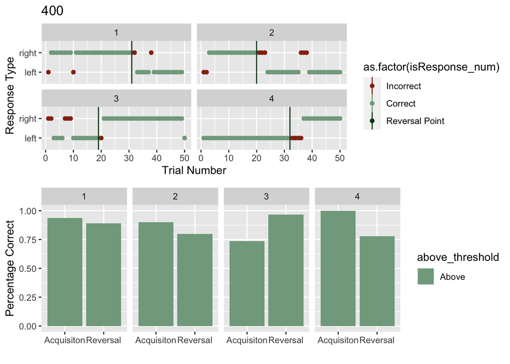

### cowplot_list 3

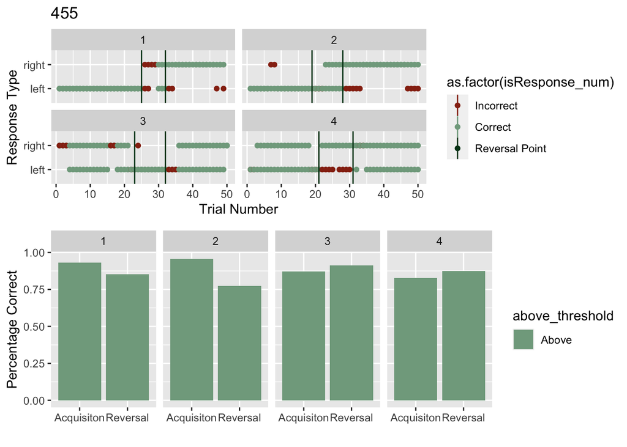

### cowplot_list 4

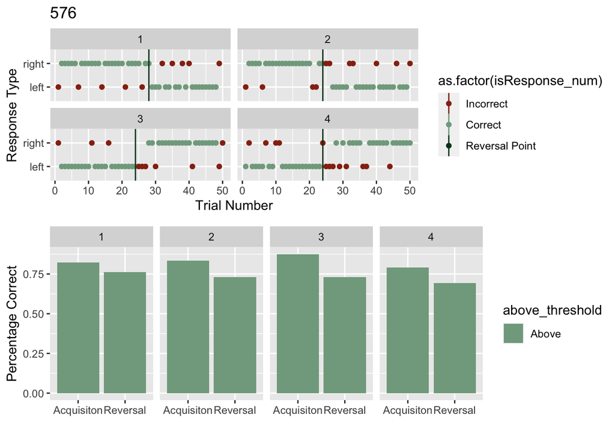

### cowplot_list 5

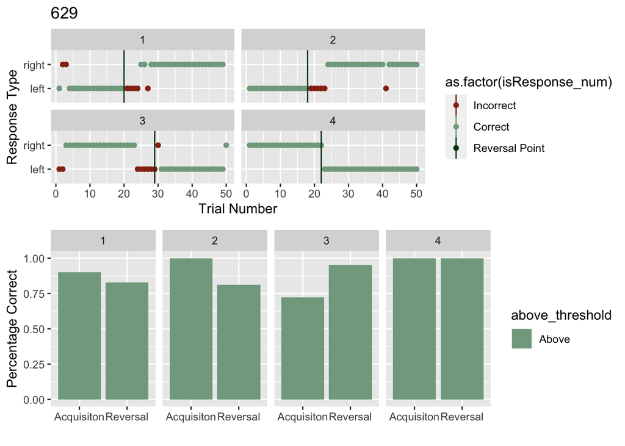

### cowplot_list 6

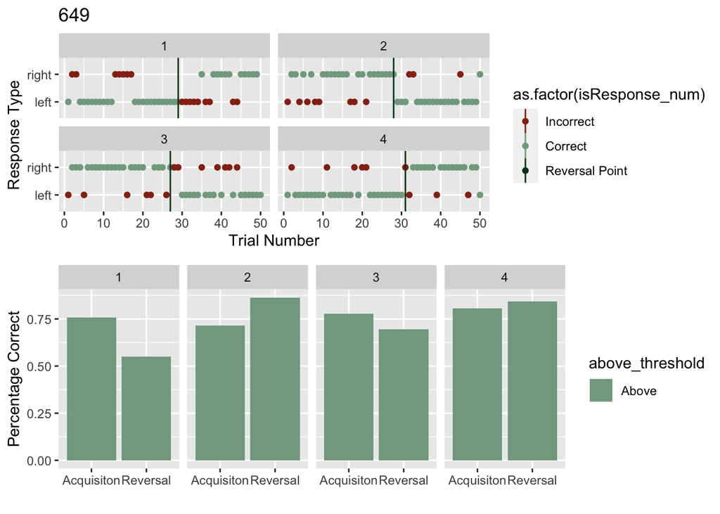

### cowplot_list 7

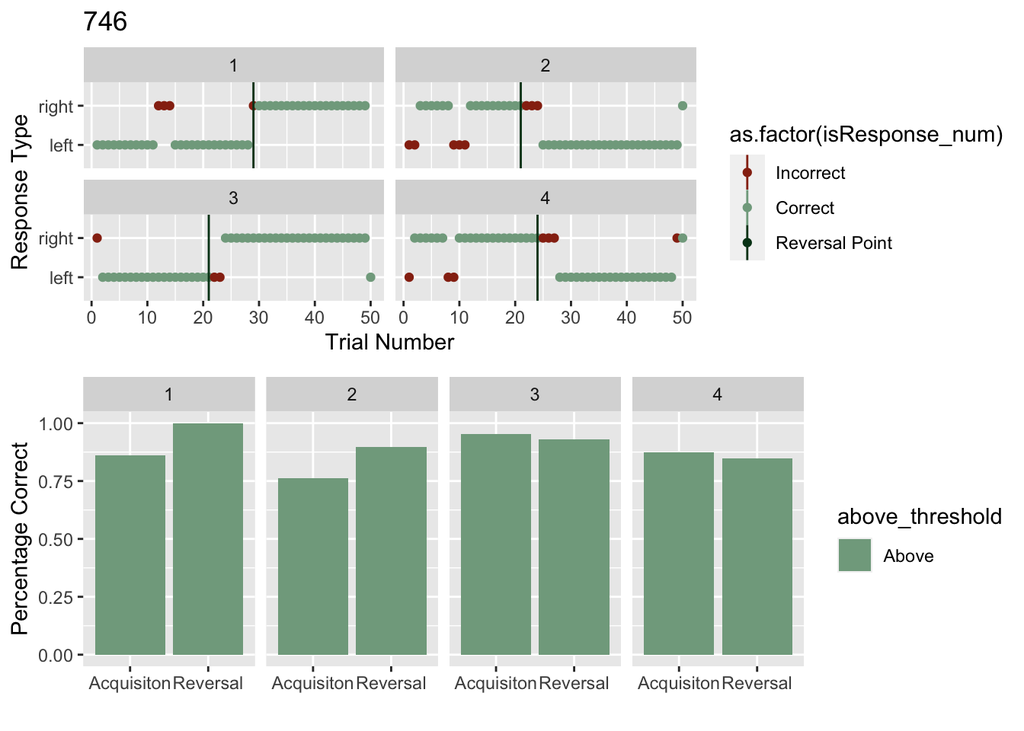

### cowplot_list 8

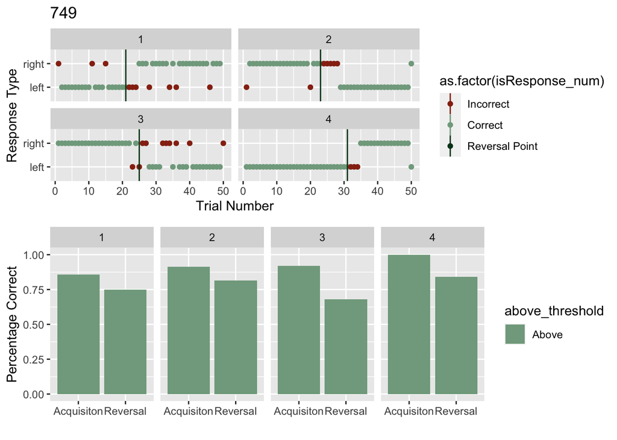

### cowplot_list 9

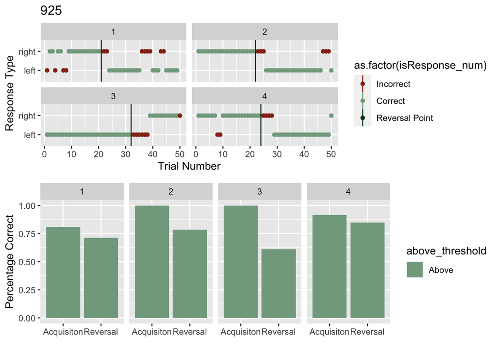

### cowplot_list 10

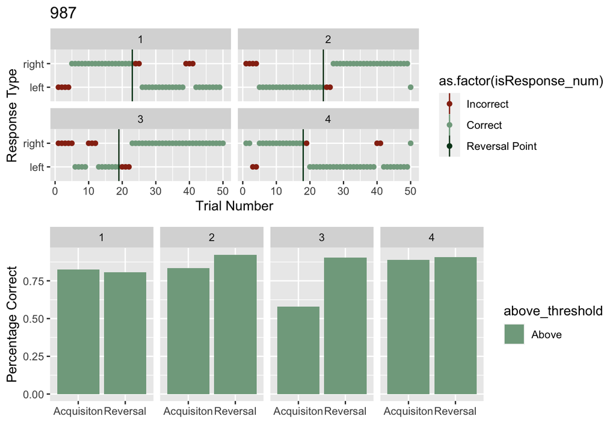

## Hisotry of MD Changes

#### Pilot Findings Summary

On average, participants made the “correct” choice approximately 80% of the time, and made at least 10 correct choices by trial 17. Both of these outcomes suggest the block length can be shortened as suggested by MNH to as little as 50 trials. Regarding data verification and visualization, it will be important to look at RT data more explicitly in the larger sample. Based on the pilot, it looks like it could be handled pretty easily with a log or invesrse transform.

### Task Reccomendations - For Michael Discussion

1. Block length to 50 trials per MNH’s suggestion. Given subjects learned the contingencies in an average of 16 trials, this seems about correct. For time’s sake, I’m thinking of erring on the side of 4 blocks of 50 trials.
2. Explicitly instruct participants to click as quickly and accurately as possible, and shorten response windows such that the entire task will take between 8 and 10 minutes. See “Task Timing” for more details. https://docs.google.com/spreadsheets/d/1V2UD28C_zAfH90BnNO3si6c0-qDUDFbHoU44rfdEt4I/edit#gid=390744519
3. Combine stimulus selection and feedback phases, to save time?
4. Collect 10-15 subjects and check for final timing.

### Data Check Plans - For Michael Discussion 8/26

1. Translate dplyr operations into usable functions and try to duplicate as little as possible across tasks.
2. drop_irregular function
3. Check RTs and provide info on possible transforms